# Preprocessing Featuring Engineering Report (3)

##### imports

```python
import yfinance as yf
import pandas as pd
import numpy as np
import matplotlib.pyplot as plt
import seaborn as sns
import sys
from sklearn.preprocessing import StandardScaler
from sklearn.decomposition import PCA
from sklearn.cluster import KMeans
from sklearn.linear_model import LogisticRegression
from sklearn.ensemble import RandomForestClassifier
from sklearn.metrics import accuracy_score, precision_score, recall_score, f1_score, confusion_matrix
import seaborn as sns
import sys
from pathlib import Path


PROJECT_ROOT = Path().resolve().parent
sys.path.insert(0, str(PROJECT_ROOT))

from src.data_io import load_sp500_data
from src.features import add_engineered_features
from src.preprocessing import time_train_test_split
from src.features import add_return_lags
from src.features import add_rolling_volatility_10d
from src.features import add_ma_10d
from src.features import sharpe_like_10d
from src.preprocessing import drop_missing_rows
from src.preprocessing import direction_encoding
from src.features import remove_non_modeling_columns, remove_low_variance_columns, calculate_corr
from src.features import find_high_corr_pairs, find_low_variance_cols, remove_low_variance_cols
from src.preprocessing import prepare_for_unsupervised
from src.preprocessing import applying_pca
from src.clustering import kmeans_elbow_plot, apply_kmeans
from src.models import train_and_predict
```

```python
#updated to be cleaner for now and future, this is moved into src files in the directory - AA
data = load_sp500_data()

data.head().T
```

```
[*********************100%***********************]  1 of 1 completed
```

| Price | 0 | 1 | 2 | 3 | 4 |
| --- | --- | --- | --- | --- | --- |
| Date | 2010-01-04 00:00:00 | 2010-01-05 00:00:00 | 2010-01-06 00:00:00 | 2010-01-07 00:00:00 | 2010-01-08 00:00:00 |
| Close | 1132.98999 | 1136.52002 | 1137.140015 | 1141.689941 | 1144.97998 |
| High | 1133.869995 | 1136.630005 | 1139.189941 | 1142.459961 | 1145.390015 |
| Low | 1116.560059 | 1129.660034 | 1133.949951 | 1131.319946 | 1136.219971 |
| Open | 1116.560059 | 1132.660034 | 1135.709961 | 1136.27002 | 1140.52002 |
| Volume | 3991400000 | 2491020000 | 4972660000 | 5270680000 | 4389590000 |

##### Previous feature engineering

```python
data = add_engineered_features(data)
```

## Section A

```python
# checking for missing values -AA

cnt_missing = data.isna().sum()

missing_perc = (cnt_missing / len(data)) * 100

#quick table of missing data

tbl_4_missing = pd.DataFrame({
    'Count of Missing': cnt_missing,
    'Percent Missing':missing_perc.round()
}).sort_values('Count of Missing')

tbl_4_missing
```

| Price | Count of Missing | Percent Missing |
| --- | --- | --- |
| Date | 0 | 0.0 |
| Close | 0 | 0.0 |
| High | 0 | 0.0 |
| Low | 0 | 0.0 |
| Open | 0 | 0.0 |
| Volume | 0 | 0.0 |
| Direction | 0 | 0.0 |
| Pct_Change | 1 | 0.0 |
| MA_3 | 2 | 0.0 |
| MA_5 | 4 | 0.0 |
| MA_10 | 9 | 0.0 |
| Volatility | 9 | 0.0 |

The table was created as an audit for missing values and shows that all NaNs exclusively occur in features created for rolling window or percent change calculations. These missing values are expected in financial time-series data when pre-processing and will be removed after the creation of all engineered features.

```python
#AA
row_miss_vals = data[data.isna().any(axis=1)]

row_miss_vals.head(10)
```

| Price | Date | Close | High | Low | Open | Volume | Pct_Change | MA_3 | MA_5 | MA_10 | Volatility | Direction |
| --- | --- | --- | --- | --- | --- | --- | --- | --- | --- | --- | --- | --- |
| 0 | 2010-01-04 | 1132.989990 | 1133.869995 | 1116.560059 | 1116.560059 | 3991400000 | NaN | NaN | NaN | NaN | NaN | Up |
| 1 | 2010-01-05 | 1136.520020 | 1136.630005 | 1129.660034 | 1132.660034 | 2491020000 | 0.003116 | NaN | NaN | NaN | NaN | Up |
| 2 | 2010-01-06 | 1137.140015 | 1139.189941 | 1133.949951 | 1135.709961 | 4972660000 | 0.000546 | 1135.550008 | NaN | NaN | NaN | Up |
| 3 | 2010-01-07 | 1141.689941 | 1142.459961 | 1131.319946 | 1136.270020 | 5270680000 | 0.004001 | 1138.449992 | NaN | NaN | NaN | Up |
| 4 | 2010-01-08 | 1144.979980 | 1145.390015 | 1136.219971 | 1140.520020 | 4389590000 | 0.002882 | 1141.269979 | 1138.663989 | NaN | NaN | Up |
| 5 | 2010-01-11 | 1146.979980 | 1149.739990 | 1142.020020 | 1145.959961 | 4255780000 | 0.001747 | 1144.549967 | 1141.461987 | NaN | NaN | Down |
| 6 | 2010-01-12 | 1136.219971 | 1143.810059 | 1131.770020 | 1143.810059 | 4716160000 | -0.009381 | 1142.726644 | 1141.401978 | NaN | NaN | Up |
| 7 | 2010-01-13 | 1145.680054 | 1148.400024 | 1133.180054 | 1137.310059 | 4170360000 | 0.008326 | 1142.960002 | 1143.109985 | NaN | NaN | Up |
| 8 | 2010-01-14 | 1148.459961 | 1150.410034 | 1143.800049 | 1145.680054 | 3915200000 | 0.002426 | 1143.453328 | 1144.463989 | NaN | NaN | Down |

Justification for missing values:

- Pct_Change() creates a Nan since there is no previous day price
- Rolling Windows (3,5,10 day) - these require prior observations which causes NaN's at the beginning of the data set
- Volatility: shows several initial NaNs because a 10 day rolling standard deviation can't compute until 10 days of returns are available.

```python
train_set, test_set = time_train_test_split(data)

print(train_set['Date'].min())
print(train_set['Date'].max())


print(test_set['Date'].min())
print(test_set['Date'].max())

print("Training Rows:", len(train_set))
print("Testing Rows:", len(test_set))
```

```
2010-01-04 00:00:00
2021-12-29 00:00:00
2021-12-30 00:00:00
2024-12-31 00:00:00
Training Rows: 3019
Testing Rows: 755
```

The training set goes from 1/4/2010 to 12/29/2021 with 3019 rows (80 split).

The test set goes from 12/30/2021 to 12/31/2024 with 755 rows (20 split).

The date is checked to confirm the data is in chronological order with the training and test sets. The Training set starts earlier and ends earlier and the test set begins immediately after the training set ends. This confirms there are no jumps or overlap. This confirms the model will only be tested on future data, that hasn't yet been seen, which prevents data leakage.

## Section B

```python
#calculating daily return -AA

#creation of different lags for short term patterns

# #we need to apply these lags now so we get these features

data = add_return_lags(data)

print(data.head(10))
```

```
Price       Date        Close         High          Low         Open  \
0     2010-01-04  1132.989990  1133.869995  1116.560059  1116.560059
1     2010-01-05  1136.520020  1136.630005  1129.660034  1132.660034
2     2010-01-06  1137.140015  1139.189941  1133.949951  1135.709961
3     2010-01-07  1141.689941  1142.459961  1131.319946  1136.270020
4     2010-01-08  1144.979980  1145.390015  1136.219971  1140.520020
5     2010-01-11  1146.979980  1149.739990  1142.020020  1145.959961
6     2010-01-12  1136.219971  1143.810059  1131.770020  1143.810059
7     2010-01-13  1145.680054  1148.400024  1133.180054  1137.310059
8     2010-01-14  1148.459961  1150.410034  1143.800049  1145.680054
9     2010-01-15  1136.030029  1147.770020  1131.390015  1147.719971

Price      Volume  Pct_Change         MA_3         MA_5        MA_10  \
0      3991400000         NaN          NaN          NaN          NaN
1      2491020000    0.003116          NaN          NaN          NaN
```

[output cut: 32 more lines]

The percent change in closing price is used to observe day to day market changes. For this, lags were engineered at 1,2,3,5, and 7 days to capture short term patterns and market reversals. The lag period was selected because in financial analysis these are the commonly used to capture immediate price movements, and then multi-day, and then weekly flutuation.

```python
#calculatiion of rolling volatility -AA

#we will do this based on the standard deviation of the 10 day daily returns

#could compute extra not sure if we need it yet...

data = add_rolling_volatility_10d(data, window=10)

data[['Date', 'return_1d', 'rolling_vol_10d']].head(20)
```

| Price | Date | return_1d | rolling_vol_10d |
| --- | --- | --- | --- |
| 0 | 2010-01-04 | NaN | NaN |
| 1 | 2010-01-05 | 0.003116 | NaN |
| 2 | 2010-01-06 | 0.000546 | NaN |
| 3 | 2010-01-07 | 0.004001 | NaN |
| 4 | 2010-01-08 | 0.002882 | NaN |
| 5 | 2010-01-11 | 0.001747 | NaN |
| 6 | 2010-01-12 | -0.009381 | NaN |
| 7 | 2010-01-13 | 0.008326 | NaN |
| 8 | 2010-01-14 | 0.002426 | NaN |
| 9 | 2010-01-15 | -0.010823 | NaN |
| 10 | 2010-01-19 | 0.012500 | 0.007075 |
| 11 | 2010-01-20 | -0.010598 | 0.008002 |
| 12 | 2010-01-21 | -0.018945 | 0.010018 |
| 13 | 2010-01-22 | -0.022141 | 0.011622 |
| 14 | 2010-01-25 | 0.004598 | 0.011754 |
| 15 | 2010-01-26 | -0.004203 | 0.011567 |
| 16 | 2010-01-27 | 0.004880 | 0.011819 |
| 17 | 2010-01-28 | -0.011818 | 0.011304 |
| 18 | 2010-01-29 | -0.009829 | 0.011021 |
| 19 | 2010-02-01 | 0.014266 | 0.012691 |

```python
#this is a 10day moving average of daily returns, might be helpful for PCA and supervised model -AA

data = add_ma_10d(data, window=10)

data[['Date', 'Close', 'return_1d', 'ma_return_10d']].head(15)
```

| Price | Date | Close | return_1d | ma_return_10d |
| --- | --- | --- | --- | --- |
| 0 | 2010-01-04 | 1132.989990 | NaN | NaN |
| 1 | 2010-01-05 | 1136.520020 | 0.003116 | NaN |
| 2 | 2010-01-06 | 1137.140015 | 0.000546 | NaN |
| 3 | 2010-01-07 | 1141.689941 | 0.004001 | NaN |
| 4 | 2010-01-08 | 1144.979980 | 0.002882 | NaN |
| 5 | 2010-01-11 | 1146.979980 | 0.001747 | NaN |
| 6 | 2010-01-12 | 1136.219971 | -0.009381 | NaN |
| 7 | 2010-01-13 | 1145.680054 | 0.008326 | NaN |
| 8 | 2010-01-14 | 1148.459961 | 0.002426 | NaN |
| 9 | 2010-01-15 | 1136.030029 | -0.010823 | NaN |
| 10 | 2010-01-19 | 1150.229980 | 0.012500 | 0.001534 |
| 11 | 2010-01-20 | 1138.040039 | -0.010598 | 0.000163 |
| 12 | 2010-01-21 | 1116.479980 | -0.018945 | -0.001787 |
| 13 | 2010-01-22 | 1091.760010 | -0.022141 | -0.004401 |
| 14 | 2010-01-25 | 1096.780029 | 0.004598 | -0.004229 |

The 10 day moving average of daily returns will tell us if the market has trendede up or down over the past 10 days. This will help remove noise and help capture actual patterns and identify short term trend behaviors.

```python
# creation of a sharpe-like Ratio - AA

data = sharpe_like_10d(data, window=10)

# double checking the ratio - AA

data[['Date', 'return_1d', 'rolling_vol_10d', 'sharpe_like_10d']].head(15)
```

| Price | Date | return_1d | rolling_vol_10d | sharpe_like_10d |
| --- | --- | --- | --- | --- |
| 0 | 2010-01-04 | NaN | NaN | NaN |
| 1 | 2010-01-05 | 0.003116 | NaN | NaN |
| 2 | 2010-01-06 | 0.000546 | NaN | NaN |
| 3 | 2010-01-07 | 0.004001 | NaN | NaN |
| 4 | 2010-01-08 | 0.002882 | NaN | NaN |
| 5 | 2010-01-11 | 0.001747 | NaN | NaN |
| 6 | 2010-01-12 | -0.009381 | NaN | NaN |
| 7 | 2010-01-13 | 0.008326 | NaN | NaN |
| 8 | 2010-01-14 | 0.002426 | NaN | NaN |
| 9 | 2010-01-15 | -0.010823 | NaN | NaN |
| 10 | 2010-01-19 | 0.012500 | 0.007075 | 1.766853 |
| 11 | 2010-01-20 | -0.010598 | 0.008002 | -1.324374 |
| 12 | 2010-01-21 | -0.018945 | 0.010018 | -1.891061 |
| 13 | 2010-01-22 | -0.022141 | 0.011622 | -1.905020 |
| 14 | 2010-01-25 | 0.004598 | 0.011754 | 0.391199 |

The Sharpe-like ratio feature is engineered by dividing daily returns by the 10 day rolling volatility. It helps to show whether the current days return is strong or weak compared to recent market movement. High values mean low risk upward market movement while low values indicate high volatility with low returns.

```python
clean_data = drop_missing_rows(data)

print(len(data)) # data before dropping NA's
print(len(clean_data)) # data after dropping NA's

data[['Date', 'return_1d', 'rolling_vol_10d', 'sharpe_like_10d']].head(15)
```

```
3774
3764
```

| Price | Date | return_1d | rolling_vol_10d | sharpe_like_10d |
| --- | --- | --- | --- | --- |
| 0 | 2010-01-04 | NaN | NaN | NaN |
| 1 | 2010-01-05 | 0.003116 | NaN | NaN |
| 2 | 2010-01-06 | 0.000546 | NaN | NaN |
| 3 | 2010-01-07 | 0.004001 | NaN | NaN |
| 4 | 2010-01-08 | 0.002882 | NaN | NaN |
| 5 | 2010-01-11 | 0.001747 | NaN | NaN |
| 6 | 2010-01-12 | -0.009381 | NaN | NaN |
| 7 | 2010-01-13 | 0.008326 | NaN | NaN |
| 8 | 2010-01-14 | 0.002426 | NaN | NaN |
| 9 | 2010-01-15 | -0.010823 | NaN | NaN |
| 10 | 2010-01-19 | 0.012500 | 0.007075 | 1.766853 |
| 11 | 2010-01-20 | -0.010598 | 0.008002 | -1.324374 |
| 12 | 2010-01-21 | -0.018945 | 0.010018 | -1.891061 |
| 13 | 2010-01-22 | -0.022141 | 0.011622 | -1.905020 |
| 14 | 2010-01-25 | 0.004598 | 0.011754 | 0.391199 |

The rows containing missing values are removed after creation of engineered features. These were expected to be NaN due to the nature and lagged features. Dropping them is important for the model to ensure we have complete data for it to use.

```python
#converting the direction column to binary - AA

clean_data = direction_encoding(clean_data)

print(clean_data[['Date', 'Direction']].head(15))
```

```
Price       Date  Direction
10    2010-01-19          0
11    2010-01-20          0
12    2010-01-21          0
13    2010-01-22          1
14    2010-01-25          0
15    2010-01-26          1
16    2010-01-27          0
17    2010-01-28          0
18    2010-01-29          1
19    2010-02-01          1
20    2010-02-02          0
21    2010-02-03          0
22    2010-02-04          1
23    2010-02-05          0
24    2010-02-08          1
```

### Feature Selection

```python
#CG/AA
# Remove non-modeling columns
clean_data = remove_non_modeling_columns(clean_data)

# Remove low-variance columns
clean_data = remove_low_variance_columns(clean_data)

# Calculate the correlation matrix
corr = calculate_corr(clean_data)

#print the correlation matrix
print(corr)
```

```
Price               Close      High       Low      Open    Volume  Pct_Change  \
Price
Close            1.000000  0.999889  0.999907  0.999799  0.117778    0.015976
High             0.999889  1.000000  0.999847  0.999923  0.122865    0.006384
Low              0.999907  0.999847  1.000000  0.999884  0.113512    0.008957
Open             0.999799  0.999923  0.999884  1.000000  0.119371   -0.000939
Volume           0.117778  0.122865  0.113512  0.119371  1.000000   -0.083271
Pct_Change       0.015976  0.006384  0.008957 -0.000939 -0.083271    1.000000
MA_3             0.999838  0.999909  0.999848  0.999928  0.119748    0.001520
MA_5             0.999656  0.999794  0.999652  0.999803  0.121536   -0.001308
MA_10            0.999233  0.999466  0.999156  0.999410  0.125348   -0.002606
Volatility       0.538603  0.543139  0.534119  0.538948  0.436175   -0.026619
Direction       -0.011258 -0.011125 -0.010813 -0.010875  0.004105   -0.039422
return_1d        0.015976  0.006384  0.008957 -0.000939 -0.083271    1.000000
return_lag_1d    0.014318  0.013738  0.016759  0.015708 -0.077220   -0.115843
return_lag_2d    0.016290  0.014484  0.017433  0.015472 -0.077145    0.067421
return_lag_3d    0.016116  0.015099  0.017597  0.016672 -0.038469   -0.037142
return_lag_5d    0.015105  0.014336  0.016255  0.015490 -0.044206   -0.001364
return_lag_7d    0.014510  0.013036  0.014595  0.013023 -0.044305    0.106740
rolling_vol_10d -0.022839 -0.017519 -0.028586 -0.022904  0.490425    0.004941
sharpe_like_10d  0.020028  0.011394  0.014344  0.005004 -0.093655    0.825428

Price                MA_3      MA_5     MA_10  Volatility  Direction  \
Price
Close            0.999838  0.999656  0.999233    0.538603  -0.011258
High             0.999909  0.999794  0.999466    0.543139  -0.011125
Low              0.999848  0.999652  0.999156    0.534119  -0.010813
Open             0.999928  0.999803  0.999410    0.538948  -0.010875
Volume           0.119748  0.121536  0.125348    0.436175   0.004105
Pct_Change       0.001520 -0.001308 -0.002606   -0.026619  -0.039422
MA_3             1.000000  0.999918  0.999554    0.539704  -0.010924
MA_5             0.999918  1.000000  0.999773    0.541260  -0.010802
MA_10            0.999554  0.999773  1.000000    0.545837  -0.010502
Volatility       0.539704  0.541260  0.545837    1.000000  -0.007889
Direction       -0.010924 -0.010802 -0.010502   -0.007889   1.000000
return_1d        0.001520 -0.001308 -0.002606   -0.026619  -0.039422
return_lag_1d    0.008239  0.003127 -0.000296   -0.048638   0.018578
return_lag_2d    0.016172  0.007942  0.002367   -0.054272  -0.014748
return_lag_3d    0.016107  0.012203  0.004550   -0.062428  -0.004019
return_lag_5d    0.015271  0.015474  0.007824   -0.062880  -0.003145
```

[output cut: 54 more lines]

```
Volume                 -0.093655
Pct_Change              0.825428
MA_3                    0.007313
MA_5                    0.004856
MA_10                   0.003072
Volatility             -0.026212
Direction              -0.033478
return_1d               0.825428
return_lag_1d          -0.028882
return_lag_2d           0.010598
return_lag_3d          -0.007627
return_lag_5d          -0.013894
return_lag_7d           0.039826
rolling_vol_10d        -0.035123
sharpe_like_10d         1.000000
```

```python
high_corr_pairs = find_high_corr_pairs(clean_data, threshold=0.9)
print("High correlations:\n", high_corr_pairs)

low_variance_cols = find_low_variance_cols(clean_data, variance_threshold=1e-6)
print("Low variance features:", low_variance_cols)

clean_data = remove_low_variance_cols(clean_data, low_variance_cols)
```

```
High correlations:
 Price               Close      High       Low      Open  Volume  Pct_Change  \
Price
Close                 NaN  0.999889  0.999907  0.999799     NaN         NaN
High             0.999889       NaN  0.999847  0.999923     NaN         NaN
Low              0.999907  0.999847       NaN  0.999884     NaN         NaN
Open             0.999799  0.999923  0.999884       NaN     NaN         NaN
Volume                NaN       NaN       NaN       NaN     NaN         NaN
Pct_Change            NaN       NaN       NaN       NaN     NaN         NaN
MA_3             0.999838  0.999909  0.999848  0.999928     NaN         NaN
MA_5             0.999656  0.999794  0.999652  0.999803     NaN         NaN
MA_10            0.999233  0.999466  0.999156  0.999410     NaN         NaN
Volatility            NaN       NaN       NaN       NaN     NaN         NaN
Direction             NaN       NaN       NaN       NaN     NaN         NaN
return_1d             NaN       NaN       NaN       NaN     NaN         NaN
return_lag_1d         NaN       NaN       NaN       NaN     NaN         NaN
return_lag_2d         NaN       NaN       NaN       NaN     NaN         NaN
return_lag_3d         NaN       NaN       NaN       NaN     NaN         NaN
return_lag_5d         NaN       NaN       NaN       NaN     NaN         NaN
return_lag_7d         NaN       NaN       NaN       NaN     NaN         NaN
rolling_vol_10d       NaN       NaN       NaN       NaN     NaN         NaN
sharpe_like_10d       NaN       NaN       NaN       NaN     NaN         NaN

Price                MA_3      MA_5     MA_10  Volatility  Direction  \
Price
Close            0.999838  0.999656  0.999233         NaN        NaN
High             0.999909  0.999794  0.999466         NaN        NaN
Low              0.999848  0.999652  0.999156         NaN        NaN
Open             0.999928  0.999803  0.999410         NaN        NaN
Volume                NaN       NaN       NaN         NaN        NaN
Pct_Change            NaN       NaN       NaN         NaN        NaN
MA_3                  NaN  0.999918  0.999554         NaN        NaN
MA_5             0.999918       NaN  0.999773         NaN        NaN
MA_10            0.999554  0.999773       NaN         NaN        NaN
Volatility            NaN       NaN       NaN         NaN        NaN
Direction             NaN       NaN       NaN         NaN        NaN
return_1d             NaN       NaN       NaN         NaN        NaN
return_lag_1d         NaN       NaN       NaN         NaN        NaN
return_lag_2d         NaN       NaN       NaN         NaN        NaN
return_lag_3d         NaN       NaN       NaN         NaN        NaN
```

[output cut: 56 more lines]

```
Pct_Change                   NaN
MA_3                         NaN
MA_5                         NaN
MA_10                        NaN
Volatility                   NaN
Direction                    NaN
return_1d                    NaN
return_lag_1d                NaN
return_lag_2d                NaN
return_lag_3d                NaN
return_lag_5d                NaN
return_lag_7d                NaN
rolling_vol_10d              NaN
sharpe_like_10d              NaN
Low variance features: []
```

## Unsupervised Feature Engineering

```python
#AA
X_train_scaled, X_test_scaled, X_train, X_test, y_train, y_test = prepare_for_unsupervised(clean_data)
```

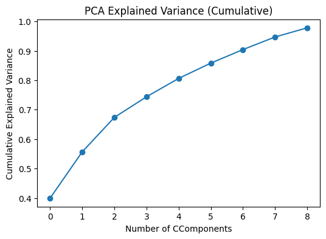

```
Number of PCA components: 9
Explained variance ratio: [0.39969652 0.1571895  0.1169881  0.06989059 0.06246396 0.05190864
 0.04595189 0.04279145 0.03116124]
```

```python
X_train_pca, X_test_pca, pca = applying_pca(X_train_scaled, X_test_scaled)

print("Number of PCA components:", pca.n_components_)
print("Explained variance ratio:", pca.explained_variance_ratio_)
```

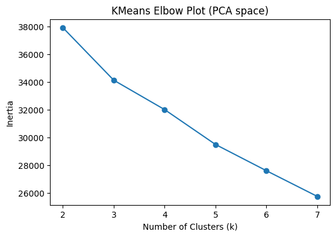

```python
kmeans_elbow_plot(X_train_pca)

train_clusters, test_clusters = apply_kmeans(X_train_pca, X_test_pca, n_clusters=3)
```

## Supervised Engineering

```python
_,log_preds,_,  rf_preds, _, _ = train_and_predict(X_train_scaled, X_test_scaled, y_train, y_test)
```

```
X_train is a pandas DataFrame.
```

```python
def evaluate_model(name, y_true, y_pred):
    print(f"\n===== {name} =====")
    print("Accuracy :", round(accuracy_score(y_true, y_pred), 4))
    print("Precision:", round(precision_score(y_true, y_pred), 4))
    print("Recall   :", round(recall_score(y_true, y_pred), 4))
    print("F1 Score :", round(f1_score(y_true, y_pred), 4))
    print("Confusion Matrix:\n", confusion_matrix(y_true, y_pred))

evaluate_model("Logistic Regression", y_test, log_preds)
evaluate_model("Random Forest", y_test, rf_preds)
```

```
===== Logistic Regression =====
Accuracy : 0.5232
Precision: 0.5194
Recall   : 0.9664
F1 Score : 0.6757
Confusion Matrix:
 [[ 20 346]
 [ 13 374]]

===== Random Forest =====
Accuracy : 0.5007
Precision: 0.5122
Recall   : 0.5943
F1 Score : 0.5502
Confusion Matrix:
 [[147 219]
 [157 230]]
```

**Review Notes:** My only feedback is we should all be careful about naming conventions for clarity and keep imports at the top - AA

**Review Notes:** We may want to plan features ahead of time, handle NaNs more efficiently, and standardize naming so everything is easier to follow. We can also check correlations and variances earlier and add small visual checks to catch issues faster. - RS

**Review Notes:** We had great use of lagged returns, rolling stats, and technical indicators. The most critical thing going forwrad from this is handling the amount of NaNs - CG

This notebook was run end-to-end on my local machine without errors - AA

This notebook was run end-to-end on my local machine without errors - RS

This notebook was run end-to-end on my local machine without errors - CG